# Hdb project

Name:Ansel Low Tze Chun  
Title: How does HDB Residential Units affect HDB properties and Facilities

## Questions To Answer

1. Which flat type had the highest number of units sold and rented each year?
2. How has the trend in the number of rented and sold units changed over the years for each flat type?
3. Which commercial property type has the highest number of rented and sold units over the years?
4. How has the trend in the number of rented commercial units changed over the years for different property types?
5. Which industrial property type has the highest number of rented units over the years, and what could be the reason for this trend?
6. How has the trend in the number of sold industrial properties changed over the years, and what does it indicate about the market demand for different property types?
7. What is the trend of rented versus sold units for each type of facility over the years?
8. How does the distribution of rented units vary across different facility types?

## Importing Libraries and Loading Datasets

```python
#importing libraries
import pandas as pd
import matplotlib.pyplot as plt
import seaborn as sns
import datetime

#Reading CSV file using Pandas
residentUnits = pd.read_csv('Datasets/NumberofSoldandRentedHDBResidentialUnits.csv')
residentUnits.head()
```

|  | financial_year | property_type | category | flat_type | no_of_units |
| --- | --- | --- | --- | --- | --- |
| 0 | 2006 | HDB | Sold | 1-room flats | 0 |
| 1 | 2006 | HDB | Sold | 2-room flats | 101 |
| 2 | 2006 | HDB | Sold | 3-room flats | 961 |
| 3 | 2006 | HDB | Sold | 4-room flats | 2290 |
| 4 | 2006 | HDB | Sold | 5-room flats | 1303 |

## Simple Text-based Analysis Using Pandas

```python
# Convert no_of_units to numeric
residentUnits['no_of_units'] = pd.to_numeric(residentUnits['no_of_units'], errors='coerce')

# Group by financial_year, category, and flat_type to find the maximum number of units
sold_rented_summary = residentUnits.groupby(['financial_year', 'category', 'flat_type'])['no_of_units'].sum().reset_index()

# Find the flat type with the highest number of units for each year
highest_sold_rented = sold_rented_summary.loc[sold_rented_summary.groupby(['financial_year', 'category'])['no_of_units'].idxmax()]

# Display the result
highest_sold_rented
```

|  | financial_year | category | flat_type | no_of_units |
| --- | --- | --- | --- | --- |
| 0 | 2006 | Rented | 1-room flats | 1929.0 |
| 10 | 2006 | Sold | 4-room flats | 2290.0 |
| 14 | 2007 | Rented | 1-room flats | 1147.0 |
| 24 | 2007 | Sold | 4-room flats | 6056.0 |
| 28 | 2008 | Rented | 1-room flats | 1238.0 |
| 38 | 2008 | Sold | 4-room flats | 2915.0 |
| 42 | 2009 | Rented | 1-room flats | 1744.0 |
| 52 | 2009 | Sold | 4-room flats | 3612.0 |
| 56 | 2010 | Rented | 1-room flats | 2033.0 |
| 66 | 2010 | Sold | 4-room flats | 5331.0 |
| 70 | 2011 | Rented | 1-room flats | 2455.0 |
| 80 | 2011 | Sold | 4-room flats | 8858.0 |
| 84 | 2012 | Rented | 1-room flats | 2734.0 |
| 94 | 2012 | Sold | 4-room flats | 6428.0 |
| 98 | 2013 | Rented | 1-room flats | 1592.0 |
| 108 | 2013 | Sold | 4-room flats | 7988.0 |
| 112 | 2014 | Rented | 1-room flats | 1505.0 |
| 122 | 2014 | Sold | 4-room flats | 13012.0 |
| 126 | 2015 | Rented | 1-room flats | 1642.0 |
| 137 | 2015 | Sold | 4-room flats | 10896.0 |
| 142 | 2016 | Rented | 1-room flats | 1810.0 |
| 153 | 2016 | Sold | 4-room flats | 10947.0 |
| 158 | 2017 | Rented | 1-room flats | 1773.0 |
| 169 | 2017 | Sold | 4-room flats | 12450.0 |
| 174 | 2018 | Rented | 1-room flats | 1707.0 |
| 185 | 2018 | Sold | 4-room flats | 7538.0 |
| 190 | 2019 | Rented | 1-room flats | 1752.0 |
| 201 | 2019 | Sold | 4-room flats | 5215.0 |
| 207 | 2020 | Rented | 2-room flats | 2701.0 |
| 217 | 2020 | Sold | 4-room flats | 3578.0 |
| 223 | 2021 | Rented | 2-room flats | 1805.0 |
| 233 | 2021 | Sold | 4-room flats | 6165.0 |

Data Visualisation Using MatplotLib  
Barchart

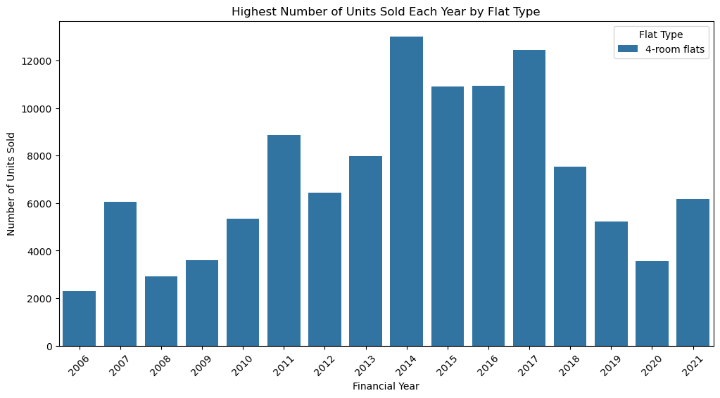

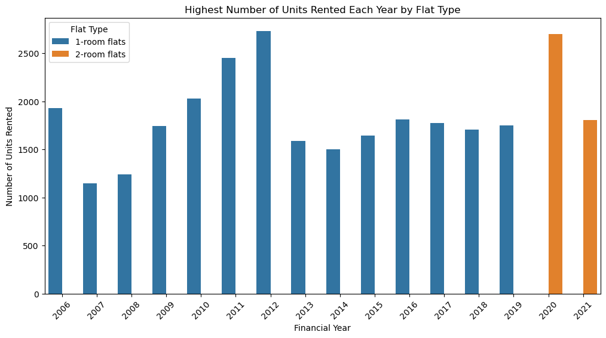

```python
# Plotting the highest number of units sold each year
plt.figure(figsize=(12, 6))
sns.barplot(x='financial_year', y='no_of_units', hue='flat_type', data=highest_sold_rented[highest_sold_rented['category'] == 'Sold'])
plt.title('Highest Number of Units Sold Each Year by Flat Type')
plt.xlabel('Financial Year')
plt.ylabel('Number of Units Sold')
plt.legend(title='Flat Type')
plt.xticks(rotation=45)
plt.show()

# Plotting the highest number of units rented each year
plt.figure(figsize=(12, 6))
sns.barplot(x='financial_year', y='no_of_units', hue='flat_type', data=highest_sold_rented[highest_sold_rented['category'] == 'Rented'])
plt.title('Highest Number of Units Rented Each Year by Flat Type')
plt.xlabel('Financial Year')
plt.ylabel('Number of Units Rented')
plt.legend(title='Flat Type')
plt.xticks(rotation=45)
plt.show()
```

## Insights gained and Explanation

Through the Data Analysis on the number of HDB residential units sold and rented each year, it reveals significant insights into market preferences and trends. Over the years, 4-room flats consistently have the highest number of units sold, highlighting their popularity among buyers likely due to their ideal balance between space and cost, appealing to families and individuals seeking more room. In contrast, the rental market is dominated by 1-room flats until 2020, reflecting a strong demand for affordable housing options among renters, particularly those with budget constraints or seeking short-term accommodations. Interestingly, starting in 2020, 2-room flats emerge as the most rented type, indicating a shift in renter preferences towards slightly larger spaces that still maintain affordability. This shift may be influenced by changing economic conditions or evolving lifestyle choices, such as the need for work-from-home spaces during the COVID-19 pandemic.

## Simple Text-based Analysis using Pandas

```python
# Group by financial_year, category, and flat_type to find the total number of units
trend_over_years = residentUnits.groupby(['financial_year', 'category', 'flat_type'])['no_of_units'].sum().unstack()

# Trend for sold units
trend_sold = trend_over_years.xs('Sold', level='category')

# Display the trend for sold units
trend_sold
```

| flat_type financial_year | 1-room flats | 2-room flats | 3-room flats | 4-room flats | 5-room flats | Executive/Multi-Generation flats | Flats sold on short leases | Studio Apartments |
| --- | --- | --- | --- | --- | --- | --- | --- | --- |
| 2006 | 0.0 | 101.0 | 961.0 | 2290.0 | 1303.0 | 1057.0 | NaN | 0.0 |
| 2007 | 0.0 | 142.0 | 1852.0 | 6056.0 | 2343.0 | 1598.0 | NaN | 0.0 |
| 2008 | 0.0 | 23.0 | 713.0 | 2915.0 | 914.0 | 173.0 | NaN | 0.0 |
| 2009 | 0.0 | 60.0 | 476.0 | 3612.0 | 778.0 | 64.0 | NaN | 0.0 |
| 2010 | 0.0 | 228.0 | 1884.0 | 5331.0 | 640.0 | 42.0 | NaN | 0.0 |
| 2011 | 0.0 | 276.0 | 1962.0 | 8858.0 | 2537.0 | 55.0 | NaN | 369.0 |
| 2012 | 0.0 | 650.0 | 2428.0 | 6428.0 | 2149.0 | 100.0 | NaN | 422.0 |
| 2013 | 0.0 | 967.0 | 2924.0 | 7988.0 | 2210.0 | 36.0 | NaN | 1079.0 |
| 2014 | 0.0 | 1224.0 | 4456.0 | 13012.0 | 6396.0 | 13.0 | NaN | 2578.0 |
| 2015 | 0.0 | 539.0 | 3515.0 | 10896.0 | 5064.0 | 8.0 | 19.0 | 1580.0 |
| 2016 | 0.0 | 588.0 | 4659.0 | 10947.0 | 5281.0 | 12.0 | 795.0 | 879.0 |
| 2017 | 0.0 | 3588.0 | 5460.0 | 12450.0 | 5351.0 | 18.0 | 1107.0 | 765.0 |
| 2018 | 0.0 | 3050.0 | 3462.0 | 7538.0 | 2556.0 | 13.0 | 890.0 | 212.0 |
| 2019 | 0.0 | 2032.0 | 2188.0 | 5215.0 | 2162.0 | 17.0 | 1409.0 | 259.0 |
| 2020 | 0.0 | 1432.0 | 1474.0 | 3578.0 | 1635.0 | 8.0 | 1071.0 | 3.0 |
| 2021 | 0.0 | 1598.0 | 2861.0 | 6165.0 | 2870.0 | 14.0 | 1444.0 | 0.0 |

```python
# Trend for rented units
trend_rented = trend_over_years.xs('Rented', level='category')

# Display the trend for sold units
trend_rented
```

| flat_type financial_year | 1-room flats | 2-room flats | 3-room flats | 4-room flats | 5-room flats | Executive/Multi-Generation flats | Flats sold on short leases | Studio Apartments |
| --- | --- | --- | --- | --- | --- | --- | --- | --- |
| 2006 | 1929.0 | 1417.0 | 688.0 | 3.0 | 0.0 | 0.0 | NaN | 0.0 |
| 2007 | 1147.0 | 1066.0 | 272.0 | 250.0 | 0.0 | 0.0 | NaN | 0.0 |
| 2008 | 1238.0 | 1200.0 | 12.0 | 0.0 | 0.0 | 0.0 | NaN | 0.0 |
| 2009 | 1744.0 | 1231.0 | 5.0 | 0.0 | 0.0 | 0.0 | NaN | 0.0 |
| 2010 | 2033.0 | 1380.0 | 1.0 | 0.0 | 0.0 | 0.0 | NaN | 0.0 |
| 2011 | 2455.0 | 1640.0 | 0.0 | 0.0 | 0.0 | 0.0 | NaN | 0.0 |
| 2012 | 2734.0 | 1695.0 | 8.0 | 14.0 | 0.0 | 0.0 | NaN | 0.0 |
| 2013 | 1592.0 | 1179.0 | 500.0 | 446.0 | 21.0 | 0.0 | NaN | 0.0 |
| 2014 | 1505.0 | 1308.0 | 52.0 | 154.0 | 74.0 | 0.0 | NaN | 0.0 |
| 2015 | 1642.0 | 1103.0 | 488.0 | 79.0 | 7.0 | 0.0 | 0.0 | 0.0 |
| 2016 | 1810.0 | 1565.0 | 307.0 | 113.0 | 4.0 | 0.0 | 0.0 | 0.0 |
| 2017 | 1773.0 | 1313.0 | 298.0 | 28.0 | 0.0 | 0.0 | 0.0 | 0.0 |
| 2018 | 1707.0 | 1324.0 | 254.0 | 35.0 | 0.0 | 0.0 | 0.0 | 0.0 |
| 2019 | 1752.0 | 1349.0 | 167.0 | 15.0 | 0.0 | 0.0 | 0.0 | 0.0 |
| 2020 | 2069.0 | 2701.0 | 165.0 | 8.0 | 0.0 | 0.0 | 0.0 | 0.0 |
| 2021 | 1335.0 | 1805.0 | 146.0 | 4.0 | 0.0 | 0.0 | 0.0 | 0.0 |

Data Visualization using Matplotlib  
Line Chart

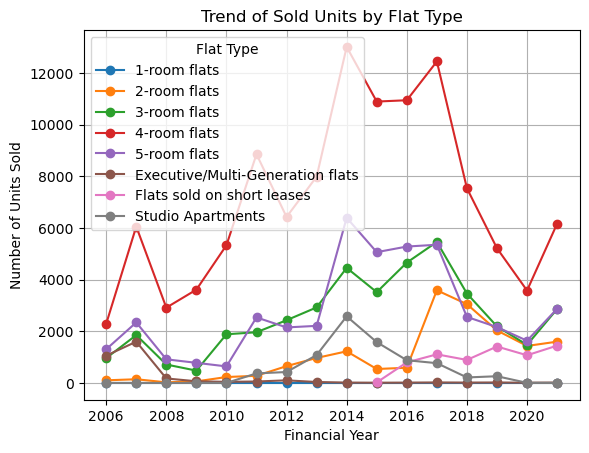

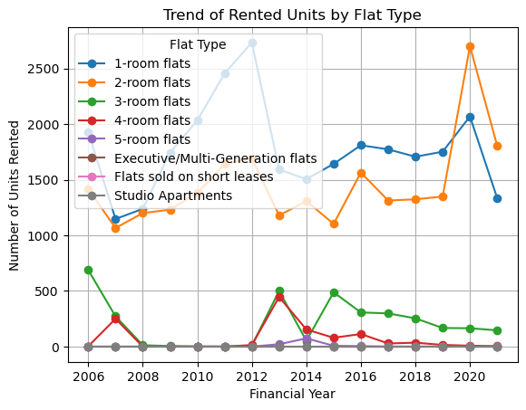

```python
# Plotting the trend for sold units
plt.figure(figsize=(12, 6))
trend_sold.plot(kind='line', marker='o', title='Trend of Sold Units by Flat Type')
plt.xlabel('Financial Year')
plt.ylabel('Number of Units Sold')
plt.legend(title='Flat Type')
plt.grid(True)
plt.show()

# Plotting the trend for rented units
plt.figure(figsize=(12, 6))
trend_rented.plot(kind='line', marker='o', title='Trend of Rented Units by Flat Type')
plt.xlabel('Financial Year')
plt.ylabel('Number of Units Rented')
plt.legend(title='Flat Type')
plt.grid(True)
plt.show()
```

## Loading Dataset and Simple Text-based Analysis using pandas

```python
#Reading CSV file using Pandas
commercialProperties = pd.read_csv('Datasets/NumberofSoldandRentedHDBCommercialProperties.csv')

# Convert no_of_units to numeric and fill NaN values with 0
commercialProperties['no_of_units'] = pd.to_numeric(commercialProperties['no_of_units'], errors='coerce').fillna(0)

# Group by property_type and category to find the total number of units
total_units = commercialProperties.groupby(['property_type', 'category'])['no_of_units'].sum().reset_index()

# Find the property type with the highest number of rented and sold units
highest_rented = total_units[total_units['category'] == 'Rented'].sort_values(by='no_of_units', ascending=False).head(1)
highest_sold = total_units[total_units['category'] == 'Sold'].sort_values(by='no_of_units', ascending=False).head(1)

print(highest_rented)
print()
print(highest_sold)

# Group by financial_year and property_type for rented units
trend_rented = commercialProperties[commercialProperties['category'] == 'Rented'].groupby(['financial_year', 'property_type'])['no_of_units'].sum().unstack()

trend_rented
```

```
             property_type category  no_of_units
8  Shops and Eating Houses   Rented       2430.0

             property_type category  no_of_units
9  Shops and Eating Houses     Sold         76.0
```

| property_type financial_year | Civil Defence Shelters (commercial use) | Eating Houses | Offices | Shops | Shops and Eating Houses | Supermarkets & Emporiums |
| --- | --- | --- | --- | --- | --- | --- |
| 2006 | 23.0 | NaN | 112.0 | NaN | 287.0 | 6.0 |
| 2007 | 3.0 | NaN | 200.0 | NaN | 330.0 | 9.0 |
| 2008 | 26.0 | NaN | 131.0 | NaN | 254.0 | 3.0 |
| 2009 | 4.0 | NaN | 78.0 | NaN | 204.0 | 5.0 |
| 2010 | 6.0 | NaN | 55.0 | NaN | 128.0 | 2.0 |
| 2011 | 10.0 | NaN | 48.0 | NaN | 105.0 | 3.0 |
| 2012 | 1.0 | NaN | 38.0 | NaN | 92.0 | 3.0 |
| 2013 | 8.0 | NaN | 62.0 | NaN | 131.0 | 5.0 |
| 2014 | 0.0 | NaN | 49.0 | NaN | 158.0 | 9.0 |
| 2015 | 10.0 | NaN | 39.0 | NaN | 192.0 | 20.0 |
| 2016 | 10.0 | NaN | 61.0 | NaN | 274.0 | 25.0 |
| 2017 | 1.0 | NaN | 63.0 | NaN | 275.0 | 25.0 |
| 2018 | 4.0 | 13.0 | 135.0 | 481.0 | NaN | 29.0 |
| 2019 | 16.0 | 32.0 | 105.0 | 280.0 | NaN | 28.0 |
| 2020 | 16.0 | 19.0 | 125.0 | 280.0 | NaN | 20.0 |
| 2021 | 7.0 | 24.0 | 110.0 | 218.0 | NaN | 10.0 |

Data visualization using Matplotlib  
Pie Chart

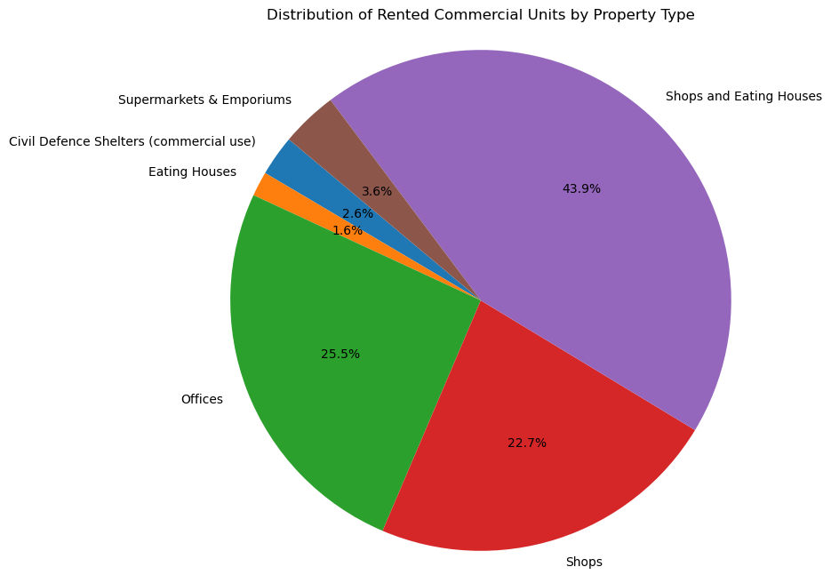

```python
# Total rented units by property type
total_rented_units = commercialProperties[commercialProperties['category'] == 'Rented'].groupby('property_type')['no_of_units'].sum()

# Plotting a pie chart
plt.figure(figsize=(8, 8))
plt.pie(total_rented_units, labels=total_rented_units.index, autopct='%1.1f%%', startangle=140)
plt.title('Distribution of Rented Commercial Units by Property Type')
plt.axis('equal')  # Equal aspect ratio ensures that pie is drawn as a circle.
plt.show()
```

## Insights gained and Explanation

The analysis of the dataset reveals that Shops and Eating Houses have the highest number of rented units, with a total of 2,430 units rented over the years. This trend underscores the critical role that retail and dining spaces play in Singapore's urban landscape. The strong demand for these rented spaces highlights the vibrant consumer culture and the importance of accessible dining and shopping experiences in the community. This demand is likely driven by factors such as population growth, increased consumer spending, and the proliferation of small businesses and eateries catering to diverse consumer preferences.

In contrast, the sales data for Shops and Eating Houses indicates that only 76 units have been sold, which suggests that while these properties are highly sought after for rental purposes, they are less frequently transacted as sales properties. This could be due to the high costs associated with purchasing retail properties or strategic choices by businesses to lease rather than own to maintain operational flexibility. The low sales figures also reflect a potential scarcity in available shop properties for purchase, possibly due to long-term leasing agreements or a preference among property owners to retain these high-demand assets.

## Loading Dataset and Simple Text-based Analysis using pandas

```python
#Reading CSV file using Pandas
industrialProperties = pd.read_csv('Datasets/NumberofSoldandRentedHDBIndustrialProperties.csv')

# Convert no_of_units to numeric and fill NaN values with 0
industrialProperties['no_of_units'] = pd.to_numeric(industrialProperties['no_of_units'], errors='coerce').fillna(0)

# Group by property_type and category to find the total number of rented units
total_rented_units = industrialProperties[industrialProperties['category'] == 'Rented'].groupby('property_type')['no_of_units'].sum().reset_index().sort_values(by='no_of_units', ascending=False)

total_rented_units
```

|  | property_type | no_of_units |
| --- | --- | --- |
| 3 | Industrial Shops | 1211.0 |
| 6 | Terrace Workshops | 826.0 |
| 1 | Flatted/Ramp-up Factories | 640.0 |
| 2 | Industrial Complexes | 68.0 |
| 5 | TOL Land | 40.0 |
| 8 | Wholesale Centres | 23.0 |
| 7 | Warehouse | 15.0 |
| 0 | Canteens/Eating House | 9.0 |
| 4 | Prototype Factories | 4.0 |

```python
# Group by financial_year and property_type for sold units
trend_sold = industrialProperties[industrialProperties['category'] == 'Sold'].groupby('property_type')['no_of_units'].sum().reset_index().sort_values(by='no_of_units', ascending=False)
trend_sold
```

|  | property_type | no_of_units |
| --- | --- | --- |
| 0 | Canteens/Eating House | 0.0 |
| 1 | Flatted/Ramp-up Factories | 0.0 |
| 2 | Industrial Complexes | 0.0 |
| 3 | Industrial Shops | 0.0 |
| 4 | Prototype Factories | 0.0 |
| 5 | TOL Land | 0.0 |
| 6 | Terrace Workshops | 0.0 |
| 7 | Warehouse | 0.0 |
| 8 | Wholesale Centres | 0.0 |

## Data Visualization using Seaborn

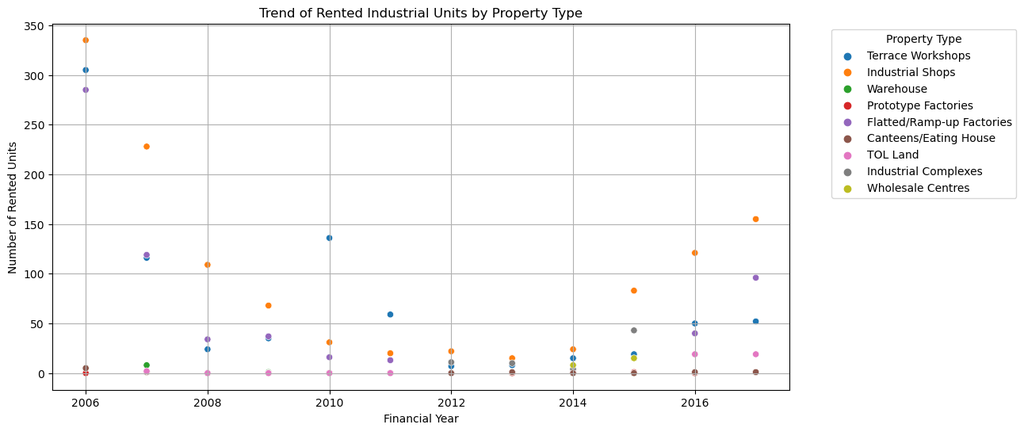

```python
# Plotting a scatterplot for rented units by property type
plt.figure(figsize=(12, 6))
sns.scatterplot(data=industrialProperties[industrialProperties['category'] == 'Rented'], x='financial_year', y='no_of_units', hue='property_type')
plt.title('Trend of Rented Industrial Units by Property Type')
plt.xlabel('Financial Year')
plt.ylabel('Number of Rented Units')
plt.legend(title='Property Type', bbox_to_anchor=(1.05, 1), loc='upper left')
plt.grid(True)
plt.show()
```

## Loading Datasets and Simple Text-based Analysis using pandas

```python
#Reading CSV file using Pandas
communalFacilities = pd.read_csv("Datasets/NumberofSoldandRentedHDBSocialCommunalFacilities.csv")

# Converting 'no_of_units' to numeric, forcing errors to NaN to handle missing values
communalFacilities['no_of_units'] = pd.to_numeric(communalFacilities['no_of_units'], errors='coerce')

# Exploring the trend of rented versus sold units over the years
trend_analysis = communalFacilities.groupby(['financial_year', 'category'])['no_of_units'].sum().reset_index()

# Exploring the distribution of rented units across different facility types
rented_units_distribution = communalFacilities[communalFacilities['category'] == 'Rented'].groupby('facility_type')['no_of_units'].sum().reset_index()

# Displaying the summarized data for insights
print("Trend Analysis of Rented vs. Sold Units:")
print(trend_analysis.head())
print("\nDistribution of Rented Units Across Facility Types:")
print(rented_units_distribution.head())
```

```
Trend Analysis of Rented vs. Sold Units:
   financial_year category  no_of_units
0            2006   Rented         83.0
1            2006     Sold          0.0
2            2007   Rented         63.0
3            2007     Sold          0.0
4            2008   Rented         56.0

Distribution of Rented Units Across Facility Types:
                                       facility_type  no_of_units
0                                  Active Ageing Hub         25.0
1                                  Childcare Centres        610.0
2                                  Community Centres         17.0
3                               Day Activity Centres         14.0
4  Day Activity Centres (Disabled & Senior Citizens)         37.0
```

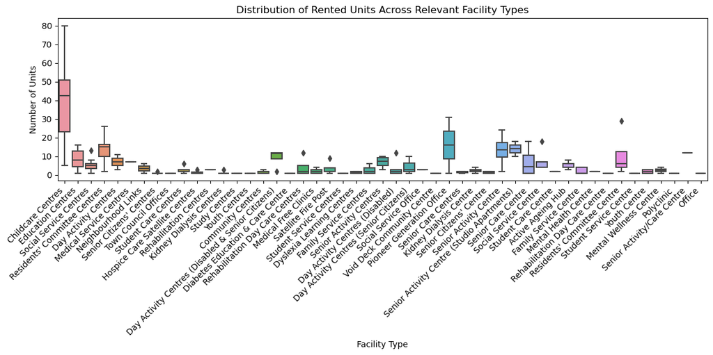

```python
# Filtering out facility types with no or minimal rented units
rented_units_summary = communalFacilities[communalFacilities['category'] == 'Rented'].groupby('facility_type')['no_of_units'].sum()
relevant_facilities = rented_units_summary[rented_units_summary > 0].index

# Filtering the dataset to include only relevant facility types
filtered_data = communalFacilities[(communalFacilities['category'] == 'Rented') & (communalFacilities['facility_type'].isin(relevant_facilities))]

# Plotting the boxplot to visualize the distribution of rented units across relevant facility types
plt.figure(figsize=(12, 6))
sns.boxplot(x='facility_type', y='no_of_units', data=filtered_data)
plt.xticks(rotation=45, ha='right')
plt.title('Distribution of Rented Units Across Relevant Facility Types')
plt.xlabel('Facility Type')
plt.ylabel('Number of Units')
plt.tight_layout()
plt.show()
```

## How does the Dataset relate to one another?

The analysis of HDB residential units, commercial properties, industrial properties, and social communal facilities reveals intricate interconnections in Singapore’s real estate market, driven by evolving consumer preferences and market dynamics. These relationships highlight a complex landscape where residential development significantly influences demand for other property types and underscores the societal and economic priorities that shape urban planning and development.

Over the years, 4-room flats have consistently emerged as the most popular choice among homebuyers, highlighting their importance in Singapore's housing market. The preference for these flats can be attributed to their ideal balance between space and cost, making them appealing to families and individuals seeking more room without exorbitant prices. The strong demand for 4-room flats reflects a societal aspiration for stability and growth, as they cater to a wide demographic, including families with children and young couples planning for the future. Simultaneously, the rental market for HDB flats has shown a shift from 1-room to 2-room units starting in 2020. This transition indicates a change in renter preferences towards slightly larger spaces, possibly due to evolving lifestyle needs such as the requirement for home offices during the COVID-19 pandemic and economic considerations affecting housing affordability. The flexibility offered by rental units allows individuals to adapt to changing circumstances, which is particularly important in a rapidly evolving economic landscape.

This shifting dynamic in the residential market has direct implications for other property categories. The demand for residential units, particularly 4-room and 2-room flats, influences the need for commercial spaces, social communal facilities, and industrial properties. For instance, the strong demand for rented commercial spaces, especially Shops and Eating Houses, can be linked to the growing residential areas that require retail and dining options to serve the community. The increasing population in residential areas drives the need for accessible consumer services, highlighting the importance of retail and dining spaces in supporting vibrant community life. Similarly, the consistent demand for rented childcare centers and elderly care facilities underscores the societal focus on supporting working families and senior citizens. As residential areas expand, there is a heightened need for social infrastructure that provides essential services and improves the quality of life for residents.